# Modeling the Impact of a Household Carbon Tax in Argentina: A Microsimulation Exercise

### Model III: Tax varies according to energy source, with more pollutant sources with higher taxes, following the Canadian Model

#### Description

In this third model, we aim to recreate a more plausible carbon tax system, drawing inspiration from Canada’s approach. Like Argentina, Canada sets absolute rates in Canadian dollars per specific volume or weight of various fossil fuels, with more polluting fuels taxed at higher rates than less polluting ones. It establishes specific rates for the following fossil fuels (**canadadepartmentoffinance2025?**):

- Aviation gasoline
- Aviation turbo fuel
- Butane
- Coke
- Coke oven gas
- Combustible waste
- Ethane
- Gas liquids
- Gasoline
- Heavy fuel oil
- Kerosene
- High heat value coal
- Kerosene
- Light fuel oil
- Low heat value coal
- Marketable natural gas
- Methanol
- Naphtha
- Non-marketable natural gas
- Petroleum coke
- Pentanes plus
- Propane
- Still gas.

As in Argentina, fuel charge rates in Canada have been gradually increasing. The first carbon price introduced in Canada was set at CAD 20/CO₂t in 2019. Rates increased by CAD 10/CO₂t annually until 2022, and by CAD 15/CO₂t each year from 2023 to 2030. Thus, in 2024, the rate reached CAD 75/CO₂t, which is approximately USD 55.55/CO₂t. This is in line with the level at which middle-income countries should be pricing carbon, according to the IMF (USD 50/CO₂t)(**canadaenvironmentandclimatechange2021?**).

For the purposes of this study, we make Canada’s fuel charges comparable to those of Argentina. Using the inflation calculator provided by the Bank of Canada (**bankofcanada2025?**), we calculate a price increase of 20.24% between 2018 and 2024. Accordingly, we adjust the 2024 fuel charge rates to their 2018 equivalents. We then apply the average 2018 exchange rate between the Argentine peso and the Canadian dollar (1 Argentine Peso = 0.04856 Canadian Dollar (**exchangerates2025?**) to convert the rates into Argentine pesos. It should noted that the exchange rate signficantly fluctuate during this year.

Since not all of the energy sources mentioned above are included in this study, we will group the fossil fuels into broader categories based on the energy sources covered in this survey:

- Bottled gas / LPG in canisters (Gas envasado en garrafas): Propane, Butane, Pentanes plus
- Bulk-delivered LPG (Gas a granel):Propane, Butane Pentanes plus
- Gas in larger cylinders or tanks (Gas envasado en tubo)*:* Propane, Butane, Pentanes plus
- Markatable Natural Gas (Gas natural): Natural Gas
- Kerosene
- Other liquid fossil fuels: Gasoline, Heavy fuel oil, Light fuel oil, Methanol. Naphta
- Coal: High heat value coal, Low heat value coal, Coke, Coke oven gas. Since these fuels are rarely used by households bur rather in industrial processes, and the charges associated with them are abnormally high. In this case we are using a tax per kg of 5.6 ARS (0.3 USD at 2018 Argentina’s exchange rate) that reflects a carbon price of roughly USD 125 per tonne CO2 matching the high end of the Paris-aligned benchmark and mirroring countries like Sweden.

As we did in the case of Argentina, we will calculate an average rate per category, corresponding to the mean of the fuel charge rates applied to the relevant energy source usually used by households. For example, the tax applicable to bottled gas will be equal to the average of the rates for Propane, Butane, and Pentanes Plus. Once we have the average rates, we will apply the conversions described above to obtain values that can be compared to Argentina’s 2018 rates.

#### Code

```r
#Creating fuel charge rates for the different categories of energy sources including in the data by averaging Canada's 2024-2025 fuel charges rates

Canada_rates <- data.frame(
  energy_source= c("Propane", "Butane", "Pentanes plus", "Natural Gas", "Kerosene","Gasoline", "Heavy fuel oil", "Light fuel oil", "Methanol", "Naphta"),
  rates= c(0.1238, 0.1424, 0.1424, 0.1525, 0.2065, 0.1761, 0.2550, 0.2139, 0.0878, 0.1803))%>%
  mutate(
    rates = rates/1.2024
  )%>%
  mutate(
    rates = rates/0.04856
  )

Canada_rates
```

```
    energy_source    rates
1         Propane 2.120279
2          Butane 2.438835
3   Pentanes plus 2.438835
4     Natural Gas 2.611814
5        Kerosene 3.536653
6        Gasoline 3.016003
7  Heavy fuel oil 4.367295
8  Light fuel oil 3.663390
9        Methanol 1.503720
10         Naphta 3.087935
```

```r
#Averaging these rates into the different energy sources included in the survey
Canada_rate_per_Energy_source_in_survey <- Canada_rates%>%
  filter(energy_source == "Propane")%>%
  mutate (
    Gas_1_Garrafas = mean(c(2.120279, 2.438835, 2.438835 )),
    Gas_2_Granel = mean(c(2.120279, 2.438835, 2.438835 )),
    Gas_3_Tubo = mean(c(2.120279, 2.438835, 2.438835 )),
    Gas_4_Natural = 2.611814,
    Kerosene = 3.536653,
    Liquid_Fuels = mean(c(3.016003, 4.367295, 3.663390, 1.503720, 3.087935))
  )%>%
  select(-rates, -energy_source)%>%
  pivot_longer(cols = everything(),
               names_to = "energy_type",
               values_to = "rate")
```

#### Scenario A

##### Model

```r
elasticity <- -0.76   # Change for different scenarios
rebate_mode <- "none"  # Options: "none", "uniform", "by_quintile"
rebate_target_quintiles <- c(1, 2)  # Only used if rebate_mode == "by_quintile"
gas_increment <- 0 # Change ratio to increase / decrease tax on gas articles
fossil_increment <- 0 # Change ratio to increase / decrease tax on fossil articles
firewood_increment <- 0
rebate_share <- 0  # Ratio of revenue that goes into rebate (can't be more than 1)


# Function that applies differentiated tax rates by type of item/energy
calculate_carbon_tax <- function(cantidad, articulo,
                                 fossil = fossil_increment, #ratio of increment
                                 gas = gas_increment,
                                 wood = firewood_increment) #ratio of increment
{
  # Tax rates based on type of energy
  tax_rates <- case_when(
    # Highly polluting fossil fuels
    articulo == "A0453101" ~ 3.54* (1 + fossil),  # Kerosene
    articulo == "A0453103" ~ 3.02* (1 + fossil),  # Other fuels

    # Gas (medium emissions)
    articulo == "A0452101" ~ 2.12 * (1 + gas),  # Bottled gas in cylinders
    articulo == "A0452102" ~ 2.12 * (1 + gas),  # Bulk gas
    articulo == "A0452103" ~ 2.61 * (1 + gas),  # Natural gas - primary residence
    articulo == "A0452104" ~ 2.12 * (1 + gas),  # Gas in tubes
    articulo == "A0452105" ~ 2.61 * (1 + gas),  # Natural gas - secondary residence

    # Electricity (varies by energy matrix, but directly less polluting)
    articulo == "A0451101" ~ 0,  # Electricity - primary residence
    articulo == "A0451102" ~ 0,  # Electricity - secondary residence
    articulo == "A0451103" ~ 0,  # Electricity expenses for another residence

    # Firewood and coal (may be renewable or not depending on the source)
    articulo == "A0453102" ~ 5.6 * (1 + wood),  # Firewood and coal

    # Others
    TRUE ~ 0                     # Standard rate
  )

  # Calculate tax
  tax <- cantidad * tax_rates
  return(tax)
}
```

```r
# Step 1: calculate tax by energy type
carbon_tax_III_A <- carbon_tax %>%
  mutate(
    carbon_tax_item = map2_dbl(
      .x = cantidad,
      .y = articulo,
      .f = calculate_carbon_tax
    ),
    #original price paid
    price = monto/cantidad,
    #per unit markup after tax
    tax_per_unit = carbon_tax_item/cantidad,
    # Effective tax rate
    tax_rate = tax_per_unit / price,

    # Apply elasticity adjustment to quantity
    cantidad2 = cantidad * (1 + tax_rate) ^ elasticity,
    price2 = price * (1 + tax_rate),
    monto2 = cantidad2 * price2,
    carbon_tax_item2 = cantidad2 * tax_per_unit
  )
```

```r
# Step 2: Total tax paid by household
household_tax_III_A <- carbon_tax_III_A %>%
  group_by(id) %>%
  summarise(
    total_carbon_tax = sum(carbon_tax_item, na.rm = TRUE),
    total_carbon_tax2 = sum(carbon_tax_item2, na.rm = TRUE),
    ingtoth = first(ingtoth), # Take the first income by id (it is the same for each id)
    total_spent_energy = sum(monto, na.rm = TRUE),
    total_spent_energy2 = sum(monto2, na.rm = TRUE)
  ) %>%
  mutate(
    net_income = ingtoth - total_carbon_tax,
    net_income2 = ingtoth - total_carbon_tax2
  )
```

```r
# Step 3: Calculate quintiles based on income
household_tax_III_A <- household_tax_III_A %>%
  mutate(
    quintile= ntile(ingtoth, 5)
  )

## Step 3.1: Add rebate if any

total_revenue_III_A <- sum(household_tax_III_A$total_carbon_tax, na.rm = TRUE)
total_revenue_III_A2 <- sum(household_tax_III_A$total_carbon_tax2, na.rm = TRUE)
rebate_pool_III_A <- total_revenue_III_A2 * rebate_share

household_tax_III_A <- household_tax_III_A %>%
  mutate(
    rebate = case_when(
      rebate_mode == "uniform" ~ rebate_pool_III_A / n(),
      rebate_mode == "by_quintile" & quintile %in% rebate_target_quintiles ~
        rebate_pool_III_A / sum(quintile %in% rebate_target_quintiles),
      rebate_mode %in% c("by_quintile", "none") ~ 0,
      TRUE ~ 0
    ),
    net_income3 = net_income2 + rebate  # updated post-rebate income
  )
```

```r
# Step 4: Analyzing income
quintile_analysis_III_A <- household_tax_III_A %>%
  group_by(quintile) %>%
  summarise(
    avg_total_income = mean(ingtoth, na.rm = TRUE),
    avg_net_income = mean(net_income, na.rm = TRUE),
    avg_net_income2 = mean(net_income3, na.rm = TRUE),
    avg_tax = mean(total_carbon_tax, na.rm = TRUE),
    avg_tax2 = mean(total_carbon_tax2, na.rm = TRUE),
    avg_tax_burden = mean(total_carbon_tax/ingtoth * 100, na.rm = TRUE),
    avg_tax_burden2 = mean(total_carbon_tax2/ingtoth * 100, na.rm = TRUE)
  )

carbon_tax_with_quintile_III_A <- carbon_tax_III_A %>%
  left_join(
    household_tax_III_A %>% select(id, quintile, total_carbon_tax),
    by = "id"
  )
```

##### Outputs

**Percent change in energy expenditure as a proportion of income**

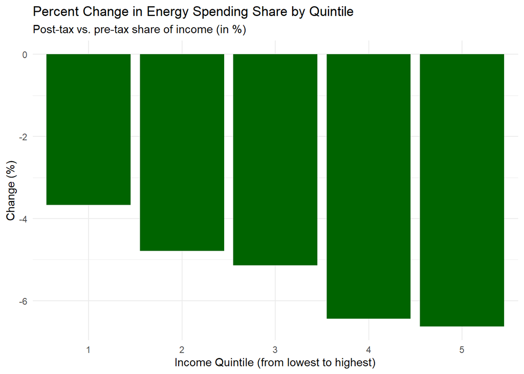

```r
tax_burden_plot_model_III_A <- household_tax_III_A %>%
  group_by(quintile) %>%
  summarise(
    share_before = sum(total_spent_energy,  na.rm = TRUE) / sum(ingtoth, na.rm = TRUE),
    share_after  = sum(total_spent_energy2, na.rm = TRUE) / sum(ingtoth, na.rm = TRUE)
  ) %>%
  # compute percent change = (after/before – 1) * 100
  mutate(
    pct_change = (share_after / share_before - 1) * 100
  ) %>%
  ggplot(aes(x = factor(quintile), y = pct_change)) +
    geom_bar(stat = "identity", fill = "darkgreen") +
    labs(
      title    = "Percent Change in Energy Spending Share by Quintile",
      subtitle = "Post-tax vs. pre-tax share of income (in %)",
      x        = "Income Quintile (from lowest to highest)",
      y        = "Change (%)"
    ) +
    theme_minimal()

print(tax_burden_plot_model_III_A)
```

**Contribution to gov income revenue**

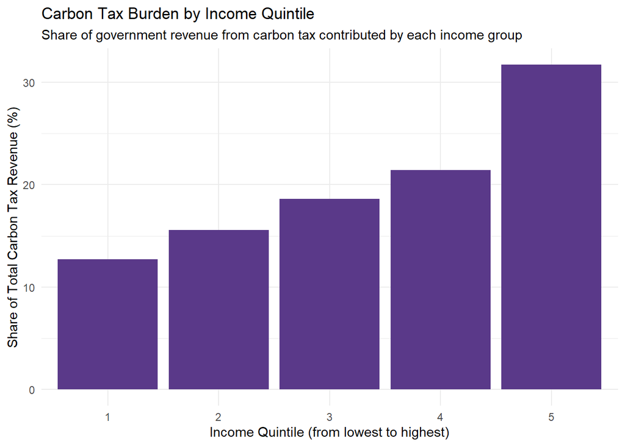

```r
quintile_contributions_III_A <- household_tax_III_A %>%
  group_by(quintile) %>%
  summarise(
    total_tax_paid = sum(total_carbon_tax2, na.rm = TRUE),
    total_income = sum(ingtoth),
    total_net_income = sum(net_income3)
  ) %>%
  mutate(
    percent_contribution = 100 * (total_tax_paid / total_revenue_III_A2),
    percent_change_income = 100 * ((total_net_income-total_income)/total_income)
  )

carbon_tax_burden_model_III_A <- ggplot(quintile_contributions_III_A, aes(x = factor(quintile), y = percent_contribution)) +
  geom_bar(stat = "identity", fill = "#5A3989") +
  labs(
 title = "Carbon Tax Burden by Income Quintile",
    subtitle = "Share of government revenue from carbon tax contributed by each income group",
    x = "Income Quintile (from lowest to highest)",
    y = "Share of Total Carbon Tax Revenue (%)"
  ) +
  theme_minimal()

print(carbon_tax_burden_model_III_A)
```

**Household percent change in net income after tax**

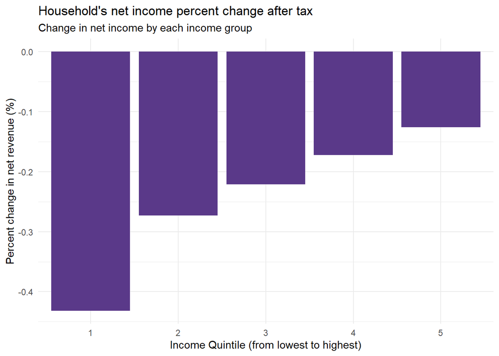

```r
net_income_model_III_A <- ggplot(quintile_contributions_III_A, aes(x = factor(quintile), y = percent_change_income)) +
  geom_bar(stat = "identity", fill = "#5A3989") +
  labs(
 title = "Household's net income percent change after tax",
    subtitle = "Change in net income by each income group",
    x = "Income Quintile (from lowest to highest)",
    y = "Percent change in net revenue (%)"
  ) +
  theme_minimal()

print(net_income_model_III_A)
```

**Geographic Analysis**

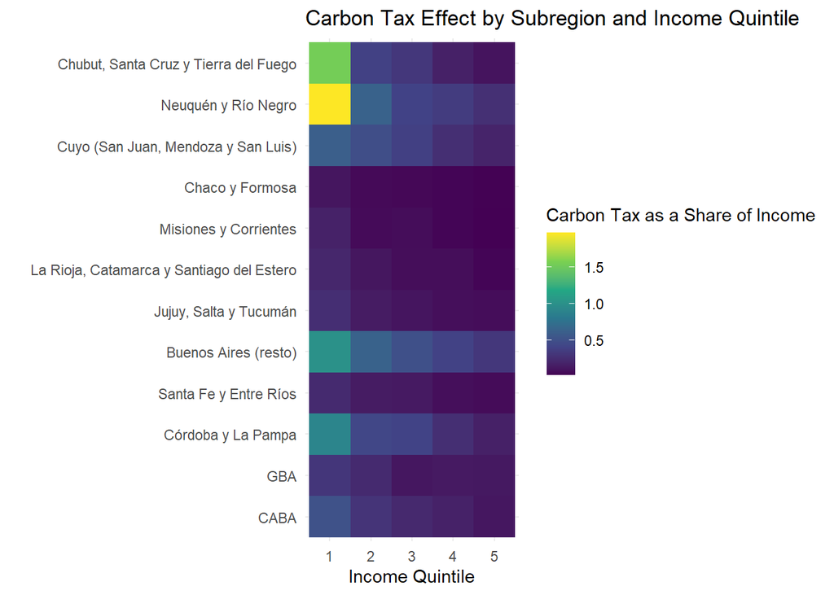

```r
# Step 1: Bring subregion info to household level
household_with_subregion_III_A <- carbon_tax_III_A %>%
  select(id, subregion) %>%
  distinct() %>%
  left_join(household_tax_III_A, by = "id")

# Step 2: Group by subregion and quintile
subregion_quintile_model_III_A <- household_with_subregion_III_A %>%
  group_by(subregion, quintile) %>%
  filter(ingtoth > 0) %>%
  summarise(
    avg_tax_pct = mean((total_carbon_tax2 / ingtoth) * 100, na.rm = TRUE),
    .groups = "drop"
  )

# Step 3: Plot
subregion_model_III_A <- ggplot(subregion_quintile_model_III_A, aes(x = factor(quintile), y = subregion, fill = avg_tax_pct)) +
  geom_tile() +
  scale_y_discrete(labels = subregion_labels) +
  scale_fill_viridis_c() +
  labs(
    title = "Carbon Tax Effect by Subregion and Income Quintile",
    x = "Income Quintile",
    y = "",
    fill = "Carbon Tax as a Share of Income"
  ) +
  theme_minimal()

print(subregion_model_III_A)
```

#### Scenario B

##### Model

```r
elasticity <- -0.76   # Change for different scenarios
rebate_mode <- "none"  # Options: "none", "uniform", "by_quintile"
rebate_target_quintiles <- c(1, 2)  # Only used if rebate_mode == "by_quintile"
gas_increment <- 0.1 # Change ratio to increase / decrease tax on gas articles
fossil_increment <- 0.5 # Change ratio to increase / decrease tax on fossil articles
firewood_increment <- 0
rebate_share <- 0  # Ratio of revenue that goes into rebate (can't be more than 1)


# Function that applies differentiated tax rates by type of item/energy
calculate_carbon_tax <- function(cantidad, articulo,
                                 fossil = fossil_increment, #ratio of increment
                                 gas = gas_increment,
                                 wood = firewood_increment) #ratio of increment
{
  # Tax rates based on type of energy
  tax_rates <- case_when(
    # Highly polluting fossil fuels
    articulo == "A0453101" ~ 3.54* (1 + fossil),  # Kerosene
    articulo == "A0453103" ~ 3.02* (1 + fossil),  # Other fuels

    # Gas (medium emissions)
    articulo == "A0452101" ~ 2.12 * (1 + gas),  # Bottled gas in cylinders
    articulo == "A0452102" ~ 2.12 * (1 + gas),  # Bulk gas
    articulo == "A0452103" ~ 2.61 * (1 + gas),  # Natural gas - primary residence
    articulo == "A0452104" ~ 2.12 * (1 + gas),  # Gas in tubes
    articulo == "A0452105" ~ 2.61 * (1 + gas),  # Natural gas - secondary residence

    # Electricity (varies by energy matrix, but directly less polluting)
    articulo == "A0451101" ~ 0,  # Electricity - primary residence
    articulo == "A0451102" ~ 0,  # Electricity - secondary residence
    articulo == "A0451103" ~ 0,  # Electricity expenses for another residence

    # Firewood and coal (may be renewable or not depending on the source)
    articulo == "A0453102" ~ 5.6 * (1 + wood),  # Firewood and coal

    # Others
    TRUE ~ 0                     # Standard rate
  )

  # Calculate tax
  tax <- cantidad * tax_rates
  return(tax)
}
```

```r
# Step 1: calculate tax by energy type
carbon_tax_III_B <- carbon_tax %>%
  mutate(
    carbon_tax_item = map2_dbl(
      .x = cantidad,
      .y = articulo,
      .f = calculate_carbon_tax
    ),
    #original price paid
    price = monto/cantidad,
    #per unit markup after tax
    tax_per_unit = carbon_tax_item/cantidad,
    # Effective tax rate
    tax_rate = tax_per_unit / price,

    # Apply elasticity adjustment to quantity
    cantidad2 = cantidad * (1 + tax_rate) ^ elasticity,
    price2 = price * (1 + tax_rate),
    monto2 = cantidad2 * price2,
    carbon_tax_item2 = cantidad2 * tax_per_unit
  )
```

```r
# Step 2: Total tax paid by household
household_tax_III_B <- carbon_tax_III_B %>%
  group_by(id) %>%
  summarise(
    total_carbon_tax = sum(carbon_tax_item, na.rm = TRUE),
    total_carbon_tax2 = sum(carbon_tax_item2, na.rm = TRUE),
    ingtoth = first(ingtoth), # Take the first income by id (it is the same for each id)
    total_spent_energy = sum(monto, na.rm = TRUE),
    total_spent_energy2 = sum(monto2, na.rm = TRUE)
  ) %>%
  mutate(
    net_income = ingtoth - total_carbon_tax,
    net_income2 = ingtoth - total_carbon_tax2
  )
```

```r
# Step 3: Calculate quintiles based on income
household_tax_III_B <- household_tax_III_B %>%
  mutate(
    quintile= ntile(ingtoth, 5)
  )

## Step 3.1: Add rebate if any

total_revenue_III_B <- sum(household_tax_III_B$total_carbon_tax, na.rm = TRUE)
total_revenue_III_B2 <- sum(household_tax_III_B$total_carbon_tax2, na.rm = TRUE)
rebate_pool_III_B <- total_revenue_III_B2 * rebate_share
net_revenue_III_B <- total_revenue_III_B2 - rebate_pool_III_B

household_tax_III_B <- household_tax_III_B %>%
  mutate(
    rebate = case_when(
      rebate_mode == "uniform" ~ rebate_pool_III_B / n(),
      rebate_mode == "by_quintile" & quintile %in% rebate_target_quintiles ~
        rebate_pool_III_B / sum(quintile %in% rebate_target_quintiles),
      rebate_mode %in% c("by_quintile", "none") ~ 0,
      TRUE ~ 0
    ),
    net_income3 = net_income + rebate  # updated post-rebate income
  )
```

```r
# Step 4: Analyzing income
quintile_analysis_III_B <- household_tax_III_B %>%
  group_by(quintile) %>%
  summarise(
    avg_total_income = mean(ingtoth, na.rm = TRUE),
    avg_net_income = mean(net_income, na.rm = TRUE),
    avg_net_income2 = mean(net_income3, na.rm = TRUE),
    avg_tax = mean(total_carbon_tax, na.rm = TRUE),
    avg_tax2 = mean(total_carbon_tax2, na.rm = TRUE),
    avg_tax_burden = mean(total_carbon_tax/ingtoth * 100, na.rm = TRUE),
    avg_tax_burden2 = mean(total_carbon_tax2/ingtoth * 100, na.rm = TRUE)
  )

carbon_tax_with_quintile_III_B <- carbon_tax_III_B %>%
  left_join(
    household_tax_III_B %>% select(id, quintile, total_carbon_tax),
    by = "id"
  )
```

##### Outputs

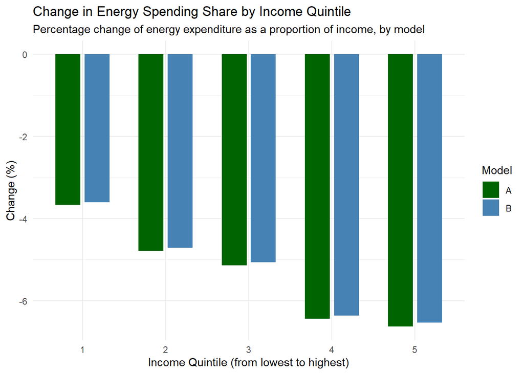

```r
pctA <- household_tax_III_A %>%
  mutate(
    income_after_rebate = ingtoth + rebate
  ) %>%
  group_by(quintile) %>%
  summarise(
    share_before = sum(total_spent_energy,  na.rm = TRUE) / sum(ingtoth, na.rm = TRUE),
    share_after  = sum(total_spent_energy2, na.rm = TRUE) / sum(income_after_rebate, na.rm = TRUE)
  ) %>%
  mutate(
    pct_change = (share_after / share_before - 1) * 100,
    pp_change = (share_after - share_before)
  )

# 2. Precompute the B pct_change
pctB <- household_tax_III_B %>%
  mutate(
    income_after_rebate = ingtoth + rebate
  ) %>%
  group_by(quintile) %>%
  summarise(
    share_before = sum(total_spent_energy,  na.rm = TRUE) / sum(ingtoth, na.rm = TRUE),
    share_after  = sum(total_spent_energy2, na.rm = TRUE) / sum(income_after_rebate, na.rm = TRUE)
  ) %>%
  mutate(
    pct_change = ((share_after / share_before) - 1) * 100,
    pp_change = (share_after - share_before)
  )

pct_change_III_B <- bind_rows(
  pctA %>% mutate(model = "A"),
  pctB %>% mutate(model = "B")
)

energy_share_change_model_III_B <- ggplot(
    pct_change_III_B,
    aes(
      x    = factor(quintile),
      y    = pct_change,
      fill = model
    )
  ) +
  geom_bar(
    stat     = "identity",
    position = position_dodge(width = 0.7),
    width    = 0.6
  ) +
  scale_fill_manual(
    values = c(A = "darkgreen", B = "steelblue"),
    name   = "Model"
  ) +
  labs(
    title    = "Change in Energy Spending Share by Income Quintile",
    subtitle = "Percentage change of energy expenditure as a proportion of income, by model",
    x        = "Income Quintile (from lowest to highest)",
    y        = "Change (%)"
  ) +
  scale_x_discrete(labels = as.character(1:5)) +
  theme_minimal()

print(energy_share_change_model_III_B)
```

**Contribution to gov income revenue**

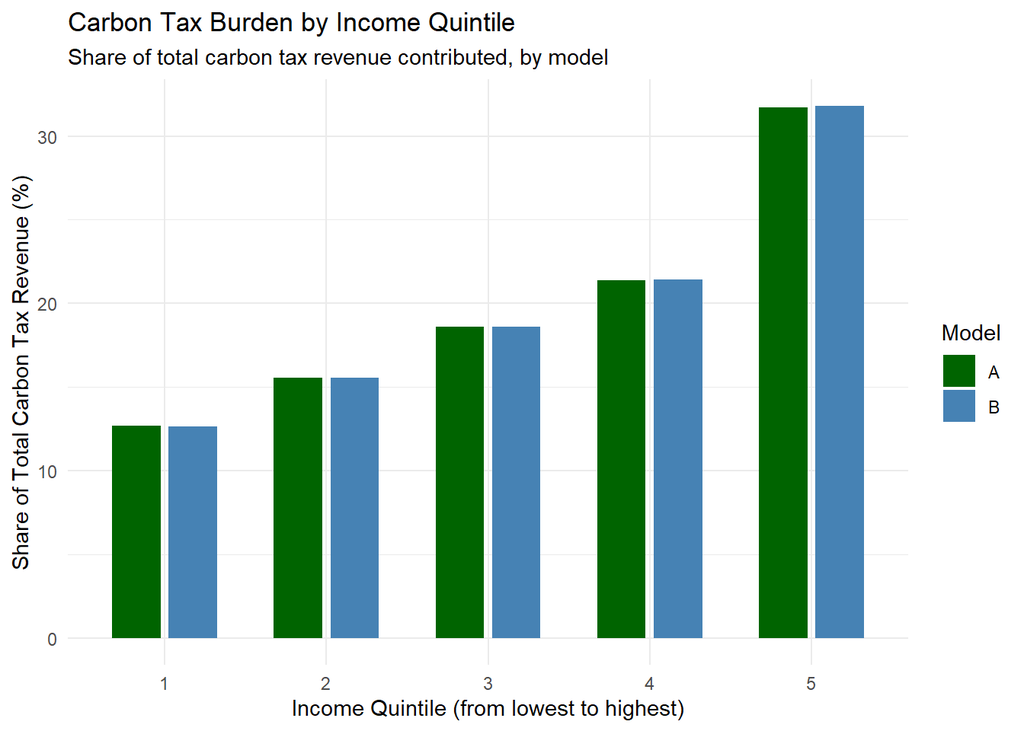

```r
quintile_contributions_III_A <- household_tax_III_A %>%
  group_by(quintile) %>%
  summarise(
    total_tax_paid    = sum(total_carbon_tax2, na.rm = TRUE),
    total_income      = sum(ingtoth, na.rm = TRUE),
    total_net_income  = sum(net_income3, na.rm = TRUE)
  ) %>%
  mutate(
    percent_contribution    = 100 * total_tax_paid/ total_revenue_III_A2,
    percent_change_income   = 100 * ((total_net_income - total_income) / total_income),
    model = "A"
  ) %>%
  select(quintile, percent_contribution, percent_change_income, model)

# 2. Summarise B (and tag it)
quintile_contributions_III_B <- household_tax_III_B %>%
  group_by(quintile) %>%
  summarise(
    total_tax_paid    = sum(total_carbon_tax2, na.rm = TRUE),
    total_income      = sum(ingtoth, na.rm = TRUE),
    total_net_income  = sum(net_income3, na.rm = TRUE),
    total_rebate      = sum(rebate, na.rm = TRUE)
  ) %>%
  mutate(
    percent_contribution    = 100 * ((total_tax_paid - total_rebate)  / net_revenue_III_B),
    percent_change_income   = 100 * ((total_net_income - total_income) / total_income),
    model = "B"
  ) %>%
  select(quintile, percent_contribution, percent_change_income, model)

quintile_contributions_III_B <- bind_rows(
  quintile_contributions_III_A,
  quintile_contributions_III_B
)

carbon_tax_burden_model_III_B <- ggplot(
    quintile_contributions_III_B,
    aes(
      x    = factor(quintile),
      y    = percent_contribution,
      fill = model
    )
  ) +
  geom_bar(
    stat     = "identity",
    position = position_dodge(width = 0.7),
    width    = 0.6
  ) +
  scale_fill_manual(
    values = c(A = "darkgreen", B = "steelblue"),
    name   = "Model"
  ) +
  labs(
    title    = "Carbon Tax Burden by Income Quintile",
    subtitle = "Share of total carbon tax revenue contributed, by model",
    x        = "Income Quintile (from lowest to highest)",
    y        = "Share of Total Carbon Tax Revenue (%)"
  ) +
  scale_x_discrete(labels = as.character(1:5)) +
  theme_minimal()

print(carbon_tax_burden_model_III_B)
```

**Household percent change in net income after tax**

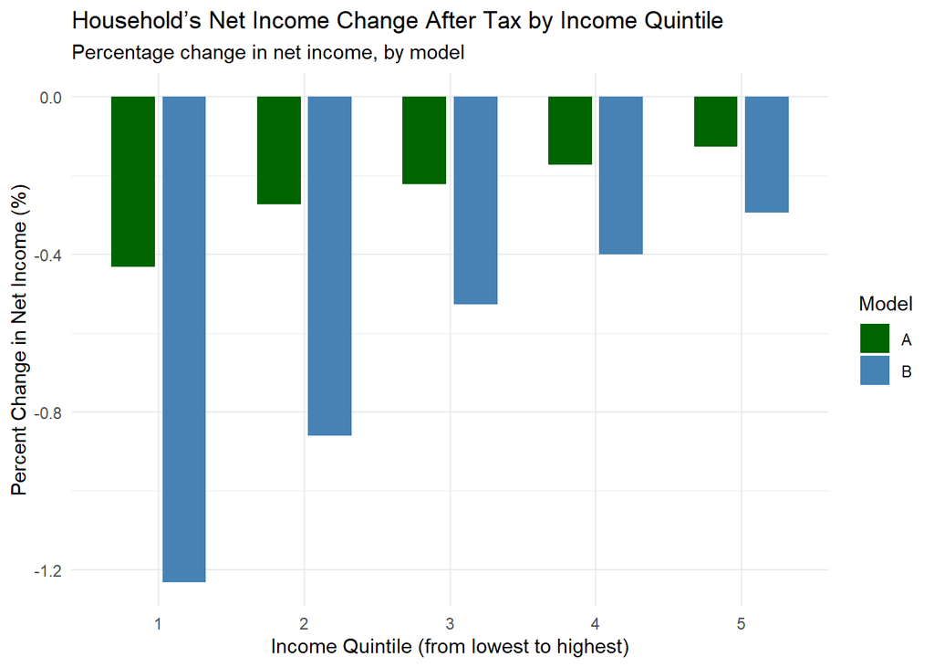

```r
net_income_model_III_B <- ggplot(
    quintile_contributions_III_B,
    aes(x = factor(quintile),
        y = percent_change_income,
        fill = model)
  ) +
  geom_bar(
    stat = "identity",
    position = position_dodge(width = 0.7),
    width = 0.6
  ) +
  labs(
    title    = "Household’s Net Income Change After Tax by Income Quintile",
    subtitle = "Percentage change in net income, by model",
    x        = "Income Quintile (from lowest to highest)",
    y        = "Percent Change in Net Income (%)",
    fill     = "Model"
  ) +
  scale_fill_manual(
    values = c(A = "darkgreen", B = "steelblue")
  ) +
  theme_minimal()

print(net_income_model_III_B)
```

**Geographic Analysis**

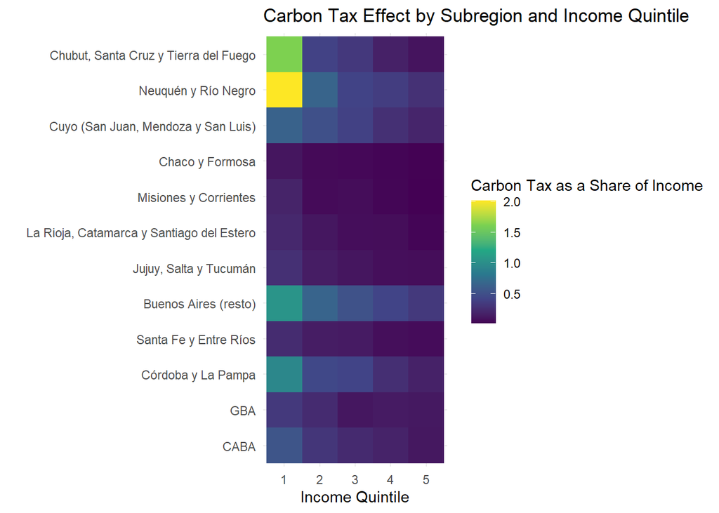

```r
# Step 1: Bring subregion info to household level
household_with_subregion_III_B <- carbon_tax_III_B %>%
  select(id, subregion) %>%
  distinct() %>%
  left_join(household_tax_III_B, by = "id")

# Step 2: Group by subregion and quintile
subregion_quintile_model_III_B <- household_with_subregion_III_B %>%
  group_by(subregion, quintile) %>%
  filter(ingtoth > 0) %>%
  summarise(
    avg_tax_pct = mean((total_carbon_tax2 / ingtoth) * 100, na.rm = TRUE),
    .groups = "drop"
  )

# Step 3: Plot
subregion_model_III_B <- ggplot(subregion_quintile_model_III_B, aes(x = factor(quintile), y = subregion, fill = avg_tax_pct)) +
  geom_tile() +
  scale_y_discrete(labels = subregion_labels) +
  scale_fill_viridis_c() +
  labs(
    title = "Carbon Tax Effect by Subregion and Income Quintile",
    x = "Income Quintile",
    y = "",
    fill = "Carbon Tax as a Share of Income"
  ) +
  theme_minimal()

print(subregion_model_III_B)
```

#### Scenario C

By doubling the fossil‐fuel tax (a 100% surcharge), we send a clear signal to curb the use of the dirtiest fuels—especially kerosene and heavy oils common in small‐scale industry and heating—while a modest 10% gas levy keeps essential cooking fuel affordable for households. With no rebates, we isolate the pure price‐signal effect, maximizing revenue (which can be channeled into clean‐energy investment) and driving significant shifts away from taxed fuels.

##### Model

```r
elasticity <- -0.76   # Change for different scenarios
rebate_mode <- "none"  # Options: "none", "uniform", "by_quintile"
rebate_target_quintiles <- c(1, 2)  # Only used if rebate_mode == "by_quintile"
gas_increment <- 0.1 # Change ratio to increase / decrease tax on gas articles
fossil_increment <- 1 # Change ratio to increase / decrease tax on fossil articles
firewood_increment <- 0
rebate_share <- 0  # Ratio of revenue that goes into rebate (can't be more than 1)


# Function that applies differentiated tax rates by type of item/energy
calculate_carbon_tax <- function(cantidad, articulo,
                                 fossil = fossil_increment, #ratio of increment
                                 gas = gas_increment,
                                 wood = firewood_increment) #ratio of increment
{
  # Tax rates based on type of energy
  tax_rates <- case_when(
    # Highly polluting fossil fuels
    articulo == "A0453101" ~ 3.54* (1 + fossil),  # Kerosene
    articulo == "A0453103" ~ 3.02* (1 + fossil),  # Other fuels

    # Gas (medium emissions)
    articulo == "A0452101" ~ 2.12 * (1 + gas),  # Bottled gas in cylinders
    articulo == "A0452102" ~ 2.12 * (1 + gas),  # Bulk gas
    articulo == "A0452103" ~ 2.61 * (1 + gas),  # Natural gas - primary residence
    articulo == "A0452104" ~ 2.12 * (1 + gas),  # Gas in tubes
    articulo == "A0452105" ~ 2.61 * (1 + gas),  # Natural gas - secondary residence

    # Electricity (varies by energy matrix, but directly less polluting)
    articulo == "A0451101" ~ 0,  # Electricity - primary residence
    articulo == "A0451102" ~ 0,  # Electricity - secondary residence
    articulo == "A0451103" ~ 0,  # Electricity expenses for another residence

    # Firewood and coal (may be renewable or not depending on the source)
    articulo == "A0453102" ~ 5.6 * (1 + wood),  # Firewood and coal

    # Others
    TRUE ~ 0                     # Standard rate
  )

  # Calculate tax
  tax <- cantidad * tax_rates
  return(tax)
}
```

```r
# Step 1: calculate tax by energy type
carbon_tax_III_C <- carbon_tax %>%
  mutate(
    carbon_tax_item = map2_dbl(
      .x = cantidad,
      .y = articulo,
      .f = calculate_carbon_tax
    ),
    #original price paid
    price = monto/cantidad,
    #per unit markup after tax
    tax_per_unit = carbon_tax_item/cantidad,
    # Effective tax rate
    tax_rate = tax_per_unit / price,

    # Apply elasticity adjustment to quantity
    cantidad2 = cantidad * (1 + tax_rate) ^ elasticity,
    price2 = price * (1 + tax_rate),
    monto2 = cantidad2 * price2,
    carbon_tax_item2 = cantidad2 * tax_per_unit
  )
```

```r
# Step 2: Total tax paid by household
household_tax_III_C <- carbon_tax_III_C %>%
  group_by(id) %>%
  summarise(
    total_carbon_tax = sum(carbon_tax_item, na.rm = TRUE),
    total_carbon_tax2 = sum(carbon_tax_item2, na.rm = TRUE),
    ingtoth = first(ingtoth), # Take the first income by id (it is the same for each id)
    total_spent_energy = sum(monto, na.rm = TRUE),
    total_spent_energy2 = sum(monto2, na.rm = TRUE)
  ) %>%
  mutate(
    net_income = ingtoth - total_carbon_tax,
    net_income2 = ingtoth - total_carbon_tax2
  )
```

```r
# Step 3: Calculate quintiles based on income
household_tax_III_C <- household_tax_III_C %>%
  mutate(
    quintile= ntile(ingtoth, 5)
  )

## Step 3.1: Add rebate if any

total_revenue_III_C <- sum(household_tax_III_C$total_carbon_tax, na.rm = TRUE)
total_revenue_III_C2 <- sum(household_tax_III_C$total_carbon_tax2, na.rm = TRUE)
rebate_pool_III_C <- total_revenue_III_C2 * rebate_share
net_revenue_III_C <- total_revenue_III_C2 - rebate_pool_III_C

household_tax_III_C <- household_tax_III_C %>%
  mutate(
    rebate = case_when(
      rebate_mode == "uniform" ~ rebate_pool_III_C / n(),
      rebate_mode == "by_quintile" & quintile %in% rebate_target_quintiles ~
        rebate_pool_III_C / sum(quintile %in% rebate_target_quintiles),
      rebate_mode %in% c("by_quintile", "none") ~ 0,
      TRUE ~ 0
    ),
    net_income3 = net_income + rebate  # updated post-rebate income
  )
```

```r
# Step 4: Analyzing income
quintile_analysis_III_C <- household_tax_III_C %>%
  group_by(quintile) %>%
  summarise(
    avg_total_income = mean(ingtoth, na.rm = TRUE),
    avg_net_income = mean(net_income, na.rm = TRUE),
    avg_net_income2 = mean(net_income3, na.rm = TRUE),
    avg_tax = mean(total_carbon_tax, na.rm = TRUE),
    avg_tax2 = mean(total_carbon_tax2, na.rm = TRUE),
    avg_tax_burden = mean(total_carbon_tax/ingtoth * 100, na.rm = TRUE),
    avg_tax_burden2 = mean(total_carbon_tax2/ingtoth * 100, na.rm = TRUE)
  )

carbon_tax_with_quintile_III_C <- carbon_tax_III_C %>%
  left_join(
    household_tax_III_C %>% select(id, quintile, total_carbon_tax),
    by = "id"
  )
```

##### Outputs

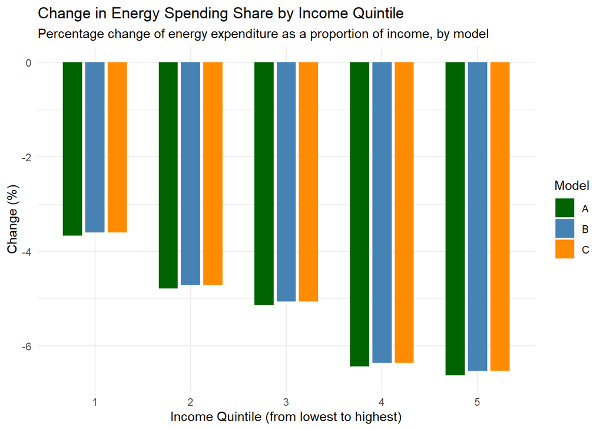

```r
# Precompute the C‐series pct_change
pctC <- household_tax_III_C %>%
  mutate(
    income_after_rebate = ingtoth + rebate
  ) %>%
  group_by(quintile) %>%
  summarise(
    share_before = sum(total_spent_energy,  na.rm = TRUE) / sum(ingtoth, na.rm = TRUE),
    share_after  = sum(total_spent_energy2, na.rm = TRUE) / sum(income_after_rebate, na.rm = TRUE)
  ) %>%
  mutate(
    pct_change = (share_after / share_before - 1) * 100,
    pp_change = (share_after - share_before)
  )

pct_change_III_C <- bind_rows(
  pct_change_III_B,
  pctC %>% mutate(model = "C")
)

energy_share_change_model_III_C <- ggplot(
    pct_change_III_C,
    aes(
      x    = factor(quintile),
      y    = pct_change,
      fill = model
    )
  ) +
  geom_bar(
    stat     = "identity",
    position = position_dodge(width = 0.7),
    width    = 0.6
  ) +
  scale_fill_manual(
    values = c(A = "darkgreen", B = "steelblue", C = "darkorange"),
    name   = "Model"
  ) +
  labs(
    title    = "Change in Energy Spending Share by Income Quintile",
    subtitle = "Percentage change of energy expenditure as a proportion of income, by model",
    x        = "Income Quintile (from lowest to highest)",
    y        = "Change (%)"
  ) +
  scale_x_discrete(labels = as.character(1:5)) +
  theme_minimal()

print(energy_share_change_model_III_C)
```

**Contribution to gov income revenue**

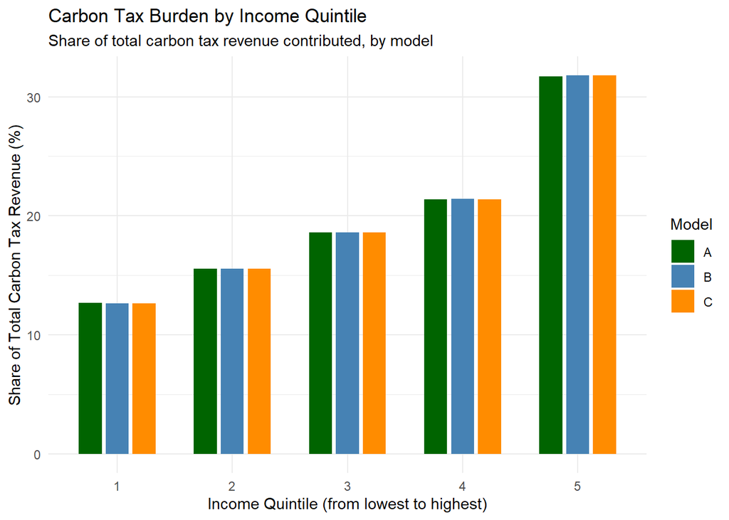

```r
# Summarise C
quintile_contributions_III_C <- household_tax_III_C %>%
  group_by(quintile) %>%
  summarise(
    total_tax_paid    = sum(total_carbon_tax2, na.rm = TRUE),
    total_income      = sum(ingtoth, na.rm = TRUE),
    total_net_income  = sum(net_income3, na.rm = TRUE),
    total_rebate      = sum(rebate, na.rm = TRUE)
  ) %>%
  mutate(
    percent_contribution    = 100 * ((total_tax_paid - total_rebate)  / net_revenue_III_C),
    percent_change_income   = 100 * ((total_net_income - total_income) / total_income),
    model = "C"
  ) %>%
  select(quintile, percent_contribution, percent_change_income, model)

quintile_contributions_III_C <- bind_rows(
  quintile_contributions_III_B,
  quintile_contributions_III_C
)

carbon_tax_burden_model_III_C <- ggplot(
    quintile_contributions_III_C,
    aes(
      x    = factor(quintile),
      y    = percent_contribution,
      fill = model
    )
  ) +
  geom_bar(
    stat     = "identity",
    position = position_dodge(width = 0.7),
    width    = 0.6
  ) +
  scale_fill_manual(
    values = c(A = "darkgreen", B = "steelblue", C = "darkorange"),
    name   = "Model"
  ) +
  labs(
    title    = "Carbon Tax Burden by Income Quintile",
    subtitle = "Share of total carbon tax revenue contributed, by model",
    x        = "Income Quintile (from lowest to highest)",
    y        = "Share of Total Carbon Tax Revenue (%)"
  ) +
  scale_x_discrete(labels = as.character(1:5)) +
  theme_minimal()

print(carbon_tax_burden_model_III_C)
```

**Household percent change in net income after tax**

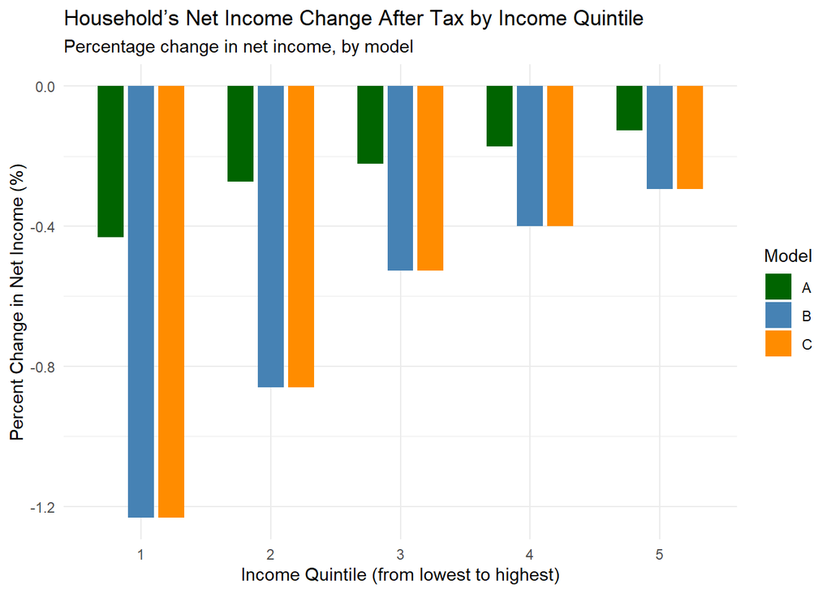

```r
net_income_model_III_C <- ggplot(
    quintile_contributions_III_C,
    aes(x = factor(quintile),
        y = percent_change_income,
        fill = model)
  ) +
  geom_bar(
    stat = "identity",
    position = position_dodge(width = 0.7),
    width = 0.6
  ) +
  labs(
    title    = "Household’s Net Income Change After Tax by Income Quintile",
    subtitle = "Percentage change in net income, by model",
    x        = "Income Quintile (from lowest to highest)",
    y        = "Percent Change in Net Income (%)",
    fill     = "Model"
  ) +
  scale_fill_manual(
    values = c(A = "darkgreen", B = "steelblue", C = "darkorange")
  ) +
  theme_minimal()

print(net_income_model_III_C)
```

**Geographic Analysis**

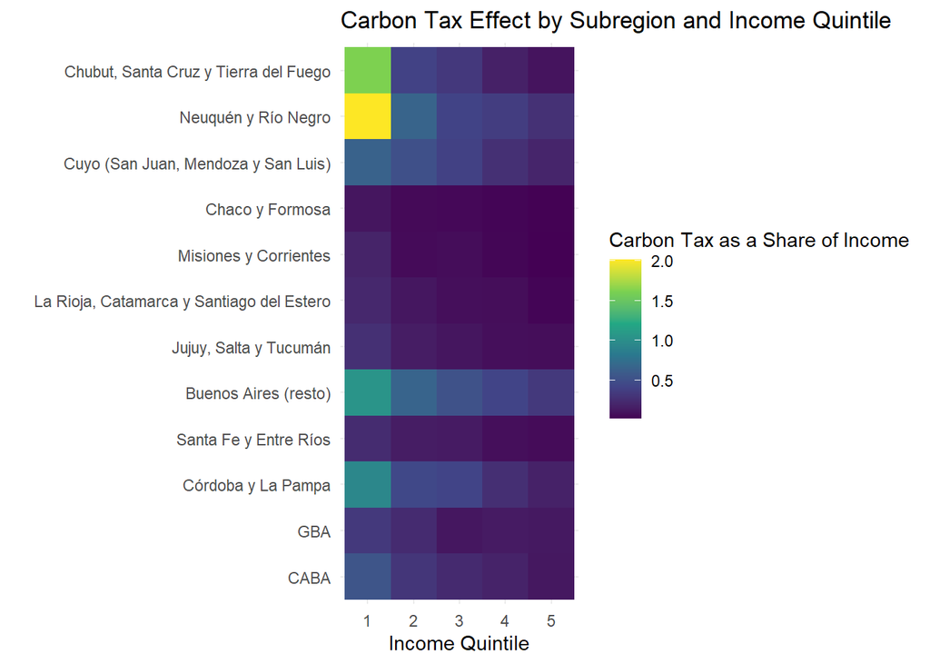

```r
# Step 1: Bring subregion info to household level
household_with_subregion_III_C <- carbon_tax_III_C %>%
  select(id, subregion) %>%
  distinct() %>%
  left_join(household_tax_III_C, by = "id")

# Step 2: Group by subregion and quintile
subregion_quintile_model_III_C <- household_with_subregion_III_C %>%
  group_by(subregion, quintile) %>%
  filter(ingtoth > 0) %>%
  summarise(
    avg_tax_pct = mean((total_carbon_tax2 / ingtoth) * 100, na.rm = TRUE),
    .groups = "drop"
  )

# Step 3: Plot
subregion_model_III_C <- ggplot(subregion_quintile_model_III_C, aes(x = factor(quintile), y = subregion, fill = avg_tax_pct)) +
  geom_tile() +
  scale_y_discrete(labels = subregion_labels) +
  scale_fill_viridis_c() +
  labs(
    title = "Carbon Tax Effect by Subregion and Income Quintile",
    x = "Income Quintile",
    y = "",
    fill = "Carbon Tax as a Share of Income"
  ) +
  theme_minimal()

print(subregion_model_III_C)
```